# Exam: MA-INF4316 Graph Representation Learning

- Wintersemester 2021/2022
- Exam: 1
- Date 2022-02-21
- Examiner: Dr. Pascal Welke

### To be filled by the student

- Name: Aleksei
- Given Name: Zhuravlev
- Matriculation number:
- Course of Studies: MSc Computer Science

(Please enter your data here)

# Task 4.1

```python
import grakel
```

```python
from grakel.datasets import fetch_dataset
DATASET = fetch_dataset("MUTAG", verbose=False, as_graphs=True)
graphs = DATASET.data
labels = DATASET.target
```

```python
rwk = grakel.RandomWalk(lamda=0.0001, kernel_type='geometric', method_type='fast')
```

```python
kernel = rwk.fit_transform(graphs)
```

```python
import numpy as np

gram_matrix = np.array(kernel) @ np.array(kernel).T
gram_matrix
```

```
array([[18624617.85594907, 14242096.79565822, 14242096.79565822, ...,
        13146588.40736175, 23007138.91629849, 17529109.46768189],
       [14242096.79565822, 10890817.8791033 , 10890817.8791033 , ...,
        10053091.34816023, 17593375.71225793, 13404370.26473753],
       [14242096.79565822, 10890817.8791033 , 10890817.8791033 , ...,
        10053091.34816023, 17593375.71225793, 13404370.26473753],
       ...,
       [13146588.40736175, 10053091.34816023, 10053091.34816023, ...,
         9279803.11270956, 16240085.46660462, 12373300.17193175],
       [23007138.91629849, 17593375.71225793, 17593375.71225793, ...,
        16240085.46660462, 28420902.12041142, 21653848.67068137],
       [17529109.46768189, 13404370.26473754, 13404370.26473754, ...,
        12373300.17193175, 21653848.67068137, 16498039.37490366]])
```

```python
print(f'G_45-G_84: {kernel[45][84]}')
print(f'G_23-G_42: {kernel[23][42]}')
print(f'G_87-G_87: {kernel[87][87]}')
```

```
G_45-G_84: 529.2917850770382
G_23-G_42: 513.2905893228317
G_87-G_87: 144.05763137538378
```

# Task 4.2

```python
from sklearn.model_selection import cross_validate
from sklearn.metrics import recall_score
from sklearn import svm

scoring = ['accuracy']
clf = svm.SVC(kernel='linear', C=1, random_state=0)
scores = cross_validate(clf, kernel, labels, scoring=scoring, cv=10)
```

```python
print(f'mean accuracy: {np.mean(scores["test_accuracy"])}, std {np.std(scores["test_accuracy"])}')
```

```
mean accuracy: 0.791812865497076, std 0.07890187123051665
```

# Task 4.3

```python
small = graphs[:50]

for lambda_ in [0.001, 0.01, 0.1, 0.2, 0.5, 0.9]:
    rwk_small = grakel.RandomWalk(lamda=lambda_, kernel_type='geometric', method_type='fast')
    kernel_small = rwk_small.fit_transform(small)
    print('lambda', lambda_)
    print(kernel_small[:3, :3])
```

```
lambda 0.001
[[290.45251269 222.07010608 222.07010608]
 [222.07010608 169.78837985 169.78837985]
 [222.07010608 169.78837985 169.78837985]]
lambda 0.01
[[304.33785326 232.28317307 232.28317307]
 [232.28317307 177.30075089 177.30075089]
 [232.28317307 177.30075089 177.30075089]]
lambda 0.1
[[637.43291573 469.03596206 469.03596206]
 [469.03596206 345.90763142 345.90763142]
 [469.03596206 345.90763142 345.90763142]]
lambda 0.2
[[ -800.56842712 -1342.61280833 -1342.61280833]
 [-1342.61280833  -828.62628264  -828.62628264]
 [-1342.61280833  -828.62628264  -828.62628264]]
lambda 0.5
[[ -74.06716166  -47.86646267  -47.86646266]
 [ -47.86646267 -146.74251374 -146.74251366]
 [ -47.86646266 -146.74251366 -146.74251377]]
```

```
lambda 0.9
[[-113.40220843  -90.06825448  -90.06825448]
 [ -90.06825448  -79.71453614  -79.71453611]
 [ -90.06825448  -79.71453611  -79.71453619]]
```

Analysis: lambda 0.001 and 0.01 are suitable, higher lambdas are not. The geometric random walk kernel converges only if $\lambda < \frac{1}{\lambda_x}$, where $\lambda_x$ is the largest eigenvalue of adjacency matrix of the product graph of two respective graphs.

# Task 4.4

```python
print(f'G_0-G_43: {kernel[0][43]}, G_0-G_0: {kernel[0][0]}, G_43-G_43: {kernel[43][43]}')
print(f'G_0-G_69: {kernel[0][69]}, G_0-G_0: {kernel[0][0]}, G_43-G_43: {kernel[69][69]}')
```

```
G_0-G_43: 289.14448468842784, G_0-G_0: 289.14448468842784, G_43-G_43: 289.14448468842784
G_0-G_69: 238.11406811874224, G_0-G_0: 289.14448468842784, G_43-G_43: 196.0900547909938
```

G_0 and G_43 are isomorphic, because the entries in kernel corresponding to G_0-G_43, G_0-G_0, and G_43-G_43 are equal. G_0 and G_69 are not isomorphic because the corresponding entries are different

# Task 4.5

```python
distance_matrix = np.zeros((len(graphs), len(graphs)))
for i in range(len(graphs)):
    for j in range(len(graphs)):
        distance_matrix[i, j] = kernel[i, i] + kernel[j, j] - 2 * kernel[i, j]

print(distance_matrix[45, 84], distance_matrix[23, 42], distance_matrix[187, 187])
```

```
-4.547473508864641e-13 64.04843847029952 0.0
```

# Task 4.6

```python
distance_matrix = np.clip(distance_matrix, 0, np.inf)
print(distance_matrix[45, 84], distance_matrix[23, 42], distance_matrix[187, 187])
```

```
0.0 64.04843847029952 0.0
```

# Task 4.7

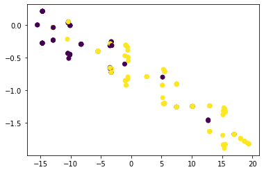

```python
from sklearn.manifold import TSNE
import matplotlib.pyplot as plt

tsne = TSNE(n_components=2, random_state=0, metric='precomputed')
emb = tsne.fit_transform(distance_matrix)
plt.scatter(emb[:, 0], emb[:, 1], c=DATASET.target)
plt.show()
```

Analysis: t-SNE outputs 2d data in such a way that similar objects are modeled by nearby points and dissimilar objects are modeled by distant points. According to the plot, the dataset can be divided into two groups of similar entries (there are some outliers, but not too many). Since graph isomorphism can be thought of as a measure of how 'similar' the graphs are, random walk kernels are well suited for classifying the MUTAG dataset.